# Risk Factor Analysis

## Outcome Variable

**Outcome Variable:** wast_rec90d

## Predictor Variables

**Intervention Variable:** mage

**Adjustment Set:**

unadjusted

## Stratifying Variables

The analysis was stratified on these variable(s):

- agecat
- studyid
- country

## Data Summary

| agecat | studyid | country | mage | wast_rec90d | n_cell | n |
| --- | --- | --- | --- | --- | --- | --- |
| 0-24 months | ki0047075b-MAL-ED | BANGLADESH | <25 | 0 | 18 | 124 |
| 0-24 months | ki0047075b-MAL-ED | BANGLADESH | <25 | 1 | 36 | 124 |
| 0-24 months | ki0047075b-MAL-ED | BANGLADESH | [25-30) | 0 | 14 | 124 |
| 0-24 months | ki0047075b-MAL-ED | BANGLADESH | [25-30) | 1 | 27 | 124 |
| 0-24 months | ki0047075b-MAL-ED | BANGLADESH | >=30 | 0 | 13 | 124 |
| 0-24 months | ki0047075b-MAL-ED | BANGLADESH | >=30 | 1 | 16 | 124 |
| 0-24 months | ki0047075b-MAL-ED | BRAZIL | <25 | 0 | 0 | 23 |
| 0-24 months | ki0047075b-MAL-ED | BRAZIL | <25 | 1 | 8 | 23 |
| 0-24 months | ki0047075b-MAL-ED | BRAZIL | [25-30) | 0 | 3 | 23 |
| 0-24 months | ki0047075b-MAL-ED | BRAZIL | [25-30) | 1 | 7 | 23 |
| 0-24 months | ki0047075b-MAL-ED | BRAZIL | >=30 | 0 | 3 | 23 |
| 0-24 months | ki0047075b-MAL-ED | BRAZIL | >=30 | 1 | 2 | 23 |
| 0-24 months | ki0047075b-MAL-ED | INDIA | <25 | 0 | 44 | 177 |
| 0-24 months | ki0047075b-MAL-ED | INDIA | <25 | 1 | 59 | 177 |
| 0-24 months | ki0047075b-MAL-ED | INDIA | [25-30) | 0 | 26 | 177 |
| 0-24 months | ki0047075b-MAL-ED | INDIA | [25-30) | 1 | 41 | 177 |
| 0-24 months | ki0047075b-MAL-ED | INDIA | >=30 | 0 | 1 | 177 |
| 0-24 months | ki0047075b-MAL-ED | INDIA | >=30 | 1 | 6 | 177 |
| 0-24 months | ki0047075b-MAL-ED | NEPAL | <25 | 0 | 9 | 93 |
| 0-24 months | ki0047075b-MAL-ED | NEPAL | <25 | 1 | 26 | 93 |
| 0-24 months | ki0047075b-MAL-ED | NEPAL | [25-30) | 0 | 10 | 93 |
| 0-24 months | ki0047075b-MAL-ED | NEPAL | [25-30) | 1 | 35 | 93 |
| 0-24 months | ki0047075b-MAL-ED | NEPAL | >=30 | 0 | 1 | 93 |
| 0-24 months | ki0047075b-MAL-ED | NEPAL | >=30 | 1 | 12 | 93 |
| 0-24 months | ki0047075b-MAL-ED | PERU | <25 | 0 | 5 | 34 |
| 0-24 months | ki0047075b-MAL-ED | PERU | <25 | 1 | 17 | 34 |
| 0-24 months | ki0047075b-MAL-ED | PERU | [25-30) | 0 | 0 | 34 |
| 0-24 months | ki0047075b-MAL-ED | PERU | [25-30) | 1 | 6 | 34 |
| 0-24 months | ki0047075b-MAL-ED | PERU | >=30 | 0 | 1 | 34 |
| 0-24 months | ki0047075b-MAL-ED | PERU | >=30 | 1 | 5 | 34 |

[output cut: 450 more lines]

The following strata were considered:

- agecat: 0-24 months, studyid: ki0047075b-MAL-ED, country: BANGLADESH
- agecat: 0-24 months, studyid: ki0047075b-MAL-ED, country: BRAZIL
- agecat: 0-24 months, studyid: ki0047075b-MAL-ED, country: INDIA
- agecat: 0-24 months, studyid: ki0047075b-MAL-ED, country: NEPAL
- agecat: 0-24 months, studyid: ki0047075b-MAL-ED, country: PERU
- agecat: 0-24 months, studyid: ki0047075b-MAL-ED, country: SOUTH AFRICA
- agecat: 0-24 months, studyid: ki0047075b-MAL-ED, country: TANZANIA, UNITED REPUBLIC OF
- agecat: 0-24 months, studyid: ki1000108-CMC-V-BCS-2002, country: INDIA
- agecat: 0-24 months, studyid: ki1000108-IRC, country: INDIA
- agecat: 0-24 months, studyid: ki1000109-EE, country: PAKISTAN
- agecat: 0-24 months, studyid: ki1000304b-SAS-CompFeed, country: INDIA
- agecat: 0-24 months, studyid: ki1000304b-SAS-FoodSuppl, country: INDIA
- agecat: 0-24 months, studyid: ki1017093-NIH-Birth, country: BANGLADESH
- agecat: 0-24 months, studyid: ki1017093b-PROVIDE, country: BANGLADESH
- agecat: 0-24 months, studyid: ki1017093c-NIH-Crypto, country: BANGLADESH
- agecat: 0-24 months, studyid: ki1066203-TanzaniaChild2, country: TANZANIA, UNITED REPUBLIC OF
- agecat: 0-24 months, studyid: ki1101329-Keneba, country: GAMBIA
- agecat: 0-24 months, studyid: ki1112895-Guatemala BSC, country: GUATEMALA
- agecat: 0-24 months, studyid: ki1112895-iLiNS-Zinc, country: BURKINA FASO
- agecat: 0-24 months, studyid: ki1113344-GMS-Nepal, country: NEPAL
- agecat: 0-24 months, studyid: ki1119695-PROBIT, country: BELARUS
- agecat: 0-24 months, studyid: ki1126311-ZVITAMBO, country: ZIMBABWE
- agecat: 0-24 months, studyid: ki1135781-COHORTS, country: GUATEMALA
- agecat: 0-24 months, studyid: ki1135781-COHORTS, country: INDIA
- agecat: 0-24 months, studyid: ki1135781-COHORTS, country: PHILIPPINES
- agecat: 0-24 months, studyid: ki1148112-LCNI-5, country: MALAWI
- agecat: 0-24 months, studyid: kiGH5241-JiVitA-3, country: BANGLADESH
- agecat: 0-6 months, studyid: ki0047075b-MAL-ED, country: BANGLADESH
- agecat: 0-6 months, studyid: ki0047075b-MAL-ED, country: BRAZIL
- agecat: 0-6 months, studyid: ki0047075b-MAL-ED, country: INDIA
- agecat: 0-6 months, studyid: ki0047075b-MAL-ED, country: NEPAL
- agecat: 0-6 months, studyid: ki0047075b-MAL-ED, country: PERU
- agecat: 0-6 months, studyid: ki0047075b-MAL-ED, country: SOUTH AFRICA
- agecat: 0-6 months, studyid: ki0047075b-MAL-ED, country: TANZANIA, UNITED REPUBLIC OF
- agecat: 0-6 months, studyid: ki1000108-CMC-V-BCS-2002, country: INDIA
- agecat: 0-6 months, studyid: ki1000108-IRC, country: INDIA
- agecat: 0-6 months, studyid: ki1000109-EE, country: PAKISTAN
- agecat: 0-6 months, studyid: ki1000304b-SAS-CompFeed, country: INDIA
- agecat: 0-6 months, studyid: ki1000304b-SAS-FoodSuppl, country: INDIA
- agecat: 0-6 months, studyid: ki1017093-NIH-Birth, country: BANGLADESH
- agecat: 0-6 months, studyid: ki1017093b-PROVIDE, country: BANGLADESH
- agecat: 0-6 months, studyid: ki1017093c-NIH-Crypto, country: BANGLADESH
- agecat: 0-6 months, studyid: ki1066203-TanzaniaChild2, country: TANZANIA, UNITED REPUBLIC OF
- agecat: 0-6 months, studyid: ki1101329-Keneba, country: GAMBIA
- agecat: 0-6 months, studyid: ki1112895-Guatemala BSC, country: GUATEMALA
- agecat: 0-6 months, studyid: ki1113344-GMS-Nepal, country: NEPAL
- agecat: 0-6 months, studyid: ki1119695-PROBIT, country: BELARUS
- agecat: 0-6 months, studyid: ki1126311-ZVITAMBO, country: ZIMBABWE
- agecat: 0-6 months, studyid: ki1135781-COHORTS, country: GUATEMALA
- agecat: 0-6 months, studyid: ki1135781-COHORTS, country: INDIA
- agecat: 0-6 months, studyid: ki1135781-COHORTS, country: PHILIPPINES
- agecat: 0-6 months, studyid: ki1148112-LCNI-5, country: MALAWI
- agecat: 0-6 months, studyid: kiGH5241-JiVitA-3, country: BANGLADESH
- agecat: 6-24 months, studyid: ki0047075b-MAL-ED, country: BANGLADESH
- agecat: 6-24 months, studyid: ki0047075b-MAL-ED, country: BRAZIL
- agecat: 6-24 months, studyid: ki0047075b-MAL-ED, country: INDIA
- agecat: 6-24 months, studyid: ki0047075b-MAL-ED, country: NEPAL
- agecat: 6-24 months, studyid: ki0047075b-MAL-ED, country: PERU
- agecat: 6-24 months, studyid: ki0047075b-MAL-ED, country: SOUTH AFRICA
- agecat: 6-24 months, studyid: ki0047075b-MAL-ED, country: TANZANIA, UNITED REPUBLIC OF
- agecat: 6-24 months, studyid: ki1000108-CMC-V-BCS-2002, country: INDIA
- agecat: 6-24 months, studyid: ki1000108-IRC, country: INDIA
- agecat: 6-24 months, studyid: ki1000109-EE, country: PAKISTAN
- agecat: 6-24 months, studyid: ki1000304b-SAS-CompFeed, country: INDIA
- agecat: 6-24 months, studyid: ki1000304b-SAS-FoodSuppl, country: INDIA
- agecat: 6-24 months, studyid: ki1017093-NIH-Birth, country: BANGLADESH
- agecat: 6-24 months, studyid: ki1017093b-PROVIDE, country: BANGLADESH
- agecat: 6-24 months, studyid: ki1017093c-NIH-Crypto, country: BANGLADESH
- agecat: 6-24 months, studyid: ki1066203-TanzaniaChild2, country: TANZANIA, UNITED REPUBLIC OF
- agecat: 6-24 months, studyid: ki1101329-Keneba, country: GAMBIA
- agecat: 6-24 months, studyid: ki1112895-Guatemala BSC, country: GUATEMALA
- agecat: 6-24 months, studyid: ki1112895-iLiNS-Zinc, country: BURKINA FASO
- agecat: 6-24 months, studyid: ki1113344-GMS-Nepal, country: NEPAL
- agecat: 6-24 months, studyid: ki1119695-PROBIT, country: BELARUS
- agecat: 6-24 months, studyid: ki1126311-ZVITAMBO, country: ZIMBABWE
- agecat: 6-24 months, studyid: ki1135781-COHORTS, country: GUATEMALA
- agecat: 6-24 months, studyid: ki1135781-COHORTS, country: INDIA
- agecat: 6-24 months, studyid: ki1135781-COHORTS, country: PHILIPPINES
- agecat: 6-24 months, studyid: ki1148112-LCNI-5, country: MALAWI
- agecat: 6-24 months, studyid: kiGH5241-JiVitA-3, country: BANGLADESH

### Dropped Strata

Some strata were dropped due to rare outcomes:

- agecat: 0-24 months, studyid: ki0047075b-MAL-ED, country: BRAZIL
- agecat: 0-24 months, studyid: ki0047075b-MAL-ED, country: INDIA
- agecat: 0-24 months, studyid: ki0047075b-MAL-ED, country: NEPAL
- agecat: 0-24 months, studyid: ki0047075b-MAL-ED, country: PERU
- agecat: 0-24 months, studyid: ki0047075b-MAL-ED, country: SOUTH AFRICA
- agecat: 0-24 months, studyid: ki0047075b-MAL-ED, country: TANZANIA, UNITED REPUBLIC OF
- agecat: 0-24 months, studyid: ki1000304b-SAS-FoodSuppl, country: INDIA
- agecat: 0-24 months, studyid: ki1112895-Guatemala BSC, country: GUATEMALA
- agecat: 0-24 months, studyid: ki1148112-LCNI-5, country: MALAWI
- agecat: 0-6 months, studyid: ki0047075b-MAL-ED, country: BANGLADESH
- agecat: 0-6 months, studyid: ki0047075b-MAL-ED, country: BRAZIL
- agecat: 0-6 months, studyid: ki0047075b-MAL-ED, country: INDIA
- agecat: 0-6 months, studyid: ki0047075b-MAL-ED, country: NEPAL
- agecat: 0-6 months, studyid: ki0047075b-MAL-ED, country: PERU
- agecat: 0-6 months, studyid: ki0047075b-MAL-ED, country: SOUTH AFRICA
- agecat: 0-6 months, studyid: ki0047075b-MAL-ED, country: TANZANIA, UNITED REPUBLIC OF
- agecat: 0-6 months, studyid: ki1000109-EE, country: PAKISTAN
- agecat: 0-6 months, studyid: ki1000304b-SAS-FoodSuppl, country: INDIA
- agecat: 0-6 months, studyid: ki1017093c-NIH-Crypto, country: BANGLADESH
- agecat: 0-6 months, studyid: ki1112895-Guatemala BSC, country: GUATEMALA
- agecat: 0-6 months, studyid: ki1148112-LCNI-5, country: MALAWI
- agecat: 6-24 months, studyid: ki0047075b-MAL-ED, country: BRAZIL
- agecat: 6-24 months, studyid: ki0047075b-MAL-ED, country: INDIA
- agecat: 6-24 months, studyid: ki0047075b-MAL-ED, country: NEPAL
- agecat: 6-24 months, studyid: ki0047075b-MAL-ED, country: PERU
- agecat: 6-24 months, studyid: ki0047075b-MAL-ED, country: SOUTH AFRICA
- agecat: 6-24 months, studyid: ki0047075b-MAL-ED, country: TANZANIA, UNITED REPUBLIC OF
- agecat: 6-24 months, studyid: ki1000108-IRC, country: INDIA
- agecat: 6-24 months, studyid: ki1000304b-SAS-FoodSuppl, country: INDIA
- agecat: 6-24 months, studyid: ki1017093c-NIH-Crypto, country: BANGLADESH
- agecat: 6-24 months, studyid: ki1112895-Guatemala BSC, country: GUATEMALA
- agecat: 6-24 months, studyid: ki1135781-COHORTS, country: GUATEMALA
- agecat: 6-24 months, studyid: ki1135781-COHORTS, country: INDIA
- agecat: 6-24 months, studyid: ki1148112-LCNI-5, country: MALAWI
- agecat: 6-24 months, studyid: kiGH5241-JiVitA-3, country: BANGLADESH

## Methods Detail

We’re interested in the causal parameters $E[Y_a]$ for all values of $a \in \mathcal{A}$. These parameters represent the mean outcome if, possibly contrary to fact, we intervened to set all units to have $A=a$. Under the randomization and positivity assumptions, these are identified by the statistical parameters $\psi_a=E_W[E_{Y|A,W}(Y|A=a,W)]$. In addition, we’re interested in the mean of $Y$, $E[Y]$ under no intervention (the observed mean). We will estimate these parameters by using SuperLearner to fit the relevant likelihood factors – $E_{Y|A,W}(Y|A=a,W)$ and $p(A=a|W)$, and then updating our likelihood fit using a joint TMLE.

For unadjusted analyses ($W=\{\}$), initial likelihoods were estimated using Lrnr_glm to estimate the simple $E(Y|A)$ and Lrnr_mean to estimate $p(A)$. For adjusted analyses, a small library containing Lrnr_glmnet, Lrnr_xgboost, and Lrnr_mean was used.

Having estimated these parameters, we will then use the delta method to estimate relative risks and attributable risks relative to a prespecified baseline level of $A$.

# Results Detail

## Results Plots

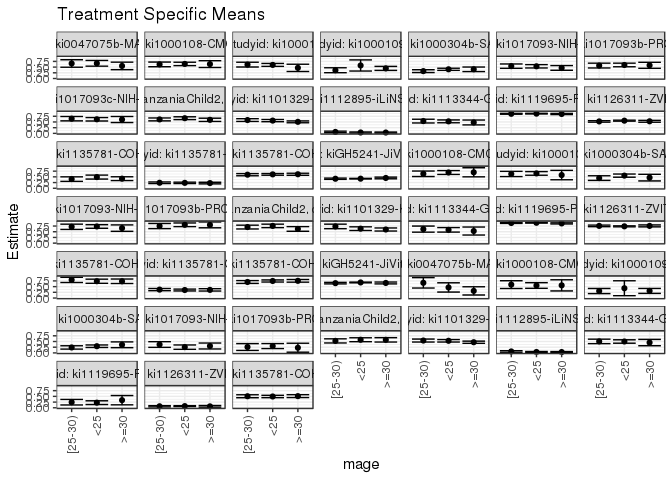

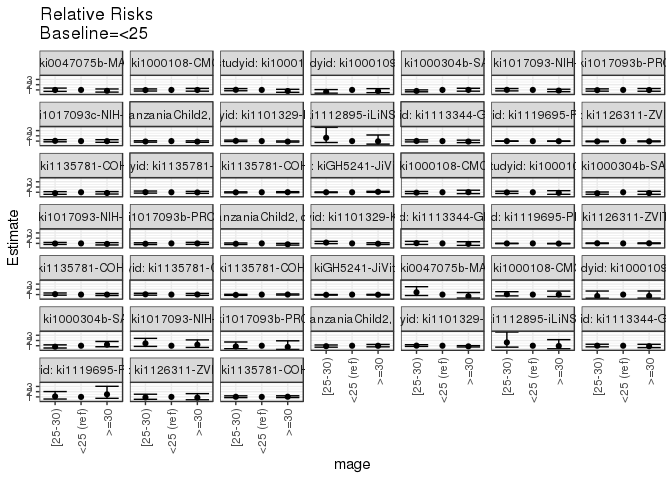

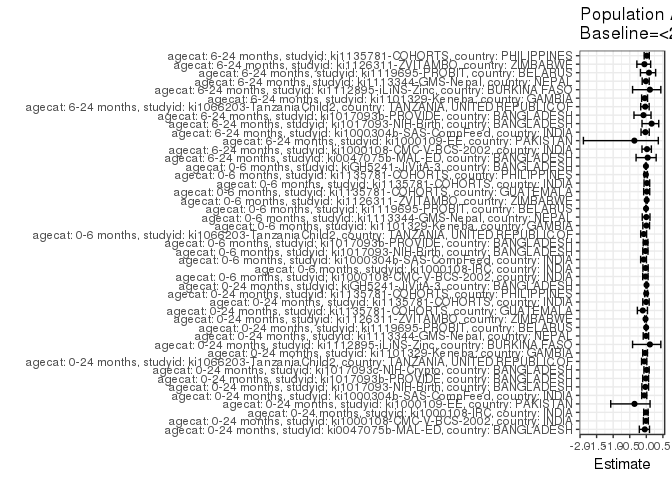

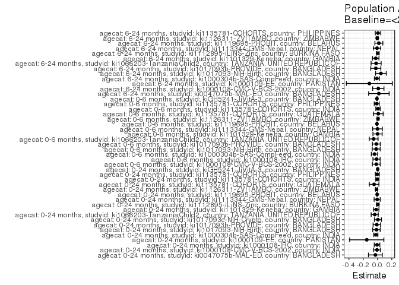

## Results Table

### Parameter: TSM

| agecat | studyid | country | intervention_level | baseline_level | estimate | ci_lower | ci_upper |
| --- | --- | --- | --- | --- | --- | --- | --- |
| 0-24 months | ki0047075b-MAL-ED | BANGLADESH | <25 | NA | 0.6666667 | 0.5414670 | 0.7918663 |
| 0-24 months | ki0047075b-MAL-ED | BANGLADESH | [25-30) | NA | 0.6585366 | 0.4945876 | 0.8224856 |
| 0-24 months | ki0047075b-MAL-ED | BANGLADESH | >=30 | NA | 0.5517241 | 0.3870228 | 0.7164254 |
| 0-24 months | ki1000108-CMC-V-BCS-2002 | INDIA | <25 | NA | 0.6387435 | 0.5643906 | 0.7130963 |
| 0-24 months | ki1000108-CMC-V-BCS-2002 | INDIA | [25-30) | NA | 0.6185567 | 0.5162792 | 0.7208342 |
| 0-24 months | ki1000108-CMC-V-BCS-2002 | INDIA | >=30 | NA | 0.6315789 | 0.4821442 | 0.7810137 |
| 0-24 months | ki1000108-IRC | INDIA | <25 | NA | 0.5960784 | 0.5321171 | 0.6600398 |
| 0-24 months | ki1000108-IRC | INDIA | [25-30) | NA | 0.6090909 | 0.5042692 | 0.7139127 |
| 0-24 months | ki1000108-IRC | INDIA | >=30 | NA | 0.4666667 | 0.3071858 | 0.6261475 |
| 0-24 months | ki1000109-EE | PAKISTAN | <25 | NA | 0.5714286 | 0.3275171 | 0.8153400 |
| 0-24 months | ki1000109-EE | PAKISTAN | [25-30) | NA | 0.3626374 | 0.2548744 | 0.4704003 |
| 0-24 months | ki1000109-EE | PAKISTAN | >=30 | NA | 0.4429530 | 0.3553497 | 0.5305564 |
| 0-24 months | ki1000304b-SAS-CompFeed | INDIA | <25 | NA | 0.4037657 | 0.3572330 | 0.4502984 |
| 0-24 months | ki1000304b-SAS-CompFeed | INDIA | [25-30) | NA | 0.3232759 | 0.2618336 | 0.3847182 |
| 0-24 months | ki1000304b-SAS-CompFeed | INDIA | >=30 | NA | 0.4038462 | 0.3039523 | 0.5037401 |
| 0-24 months | ki1017093-NIH-Birth | BANGLADESH | <25 | NA | 0.5346535 | 0.4611825 | 0.6081245 |
| 0-24 months | ki1017093-NIH-Birth | BANGLADESH | [25-30) | NA | 0.5416667 | 0.4469249 | 0.6364084 |
| 0-24 months | ki1017093-NIH-Birth | BANGLADESH | >=30 | NA | 0.4639175 | 0.3608362 | 0.5669988 |
| 0-24 months | ki1017093b-PROVIDE | BANGLADESH | <25 | NA | 0.5928144 | 0.5142672 | 0.6713615 |
| 0-24 months | ki1017093b-PROVIDE | BANGLADESH | [25-30) | NA | 0.5662651 | 0.4610007 | 0.6715294 |
| 0-24 months | ki1017093b-PROVIDE | BANGLADESH | >=30 | NA | 0.5789474 | 0.4473137 | 0.7105810 |
| 0-24 months | ki1017093c-NIH-Crypto | BANGLADESH | <25 | NA | 0.6176471 | 0.5424459 | 0.6928483 |
| 0-24 months | ki1017093c-NIH-Crypto | BANGLADESH | [25-30) | NA | 0.6444444 | 0.5487876 | 0.7401013 |
| 0-24 months | ki1017093c-NIH-Crypto | BANGLADESH | >=30 | NA | 0.6078431 | 0.4757701 | 0.7399162 |
| 0-24 months | ki1066203-TanzaniaChild2 | TANZANIA, UNITED REPUBLIC OF | <25 | NA | 0.6653696 | 0.6038796 | 0.7268597 |
| 0-24 months | ki1066203-TanzaniaChild2 | TANZANIA, UNITED REPUBLIC OF | [25-30) | NA | 0.6126482 | 0.5485616 | 0.6767349 |
| 0-24 months | ki1066203-TanzaniaChild2 | TANZANIA, UNITED REPUBLIC OF | >=30 | NA | 0.5950000 | 0.5240251 | 0.6659749 |
| 0-24 months | ki1101329-Keneba | GAMBIA | <25 | NA | 0.5606362 | 0.5127592 | 0.6085132 |
| 0-24 months | ki1101329-Keneba | GAMBIA | [25-30) | NA | 0.5840708 | 0.5246601 | 0.6434815 |
| 0-24 months | ki1101329-Keneba | GAMBIA | >=30 | NA | 0.5059524 | 0.4659723 | 0.5459325 |

[output cut: 105 more lines]

### Parameter: E(Y)

| agecat | studyid | country | intervention_level | baseline_level | estimate | ci_lower | ci_upper |
| --- | --- | --- | --- | --- | --- | --- | --- |
| 0-24 months | ki0047075b-MAL-ED | BANGLADESH | NA | NA | 0.6370968 | 0.5511492 | 0.7230443 |
| 0-24 months | ki1000108-CMC-V-BCS-2002 | INDIA | NA | NA | 0.6319018 | 0.5759256 | 0.6878781 |
| 0-24 months | ki1000108-IRC | INDIA | NA | NA | 0.5898734 | 0.5376978 | 0.6420491 |
| 0-24 months | ki1000109-EE | PAKISTAN | NA | NA | 0.4212598 | 0.3553979 | 0.4871218 |
| 0-24 months | ki1000304b-SAS-CompFeed | INDIA | NA | NA | 0.3808354 | 0.3457640 | 0.4159068 |
| 0-24 months | ki1017093-NIH-Birth | BANGLADESH | NA | NA | 0.5202864 | 0.4695109 | 0.5710618 |
| 0-24 months | ki1017093b-PROVIDE | BANGLADESH | NA | NA | 0.5830619 | 0.5262762 | 0.6398476 |
| 0-24 months | ki1017093c-NIH-Crypto | BANGLADESH | NA | NA | 0.6237942 | 0.5698223 | 0.6777662 |
| 0-24 months | ki1066203-TanzaniaChild2 | TANZANIA, UNITED REPUBLIC OF | NA | NA | 0.6267606 | 0.5890263 | 0.6644948 |
| 0-24 months | ki1101329-Keneba | GAMBIA | NA | NA | 0.5416116 | 0.5143001 | 0.5689232 |
| 0-24 months | ki1112895-iLiNS-Zinc | BURKINA FASO | NA | NA | 0.0435339 | 0.0292984 | 0.0577695 |
| 0-24 months | ki1113344-GMS-Nepal | NEPAL | NA | NA | 0.5222816 | 0.4773852 | 0.5671781 |
| 0-24 months | ki1119695-PROBIT | BELARUS | NA | NA | 0.8612051 | 0.8511051 | 0.8713052 |
| 0-24 months | ki1126311-ZVITAMBO | ZIMBABWE | NA | NA | 0.5442043 | 0.5277100 | 0.5606986 |
| 0-24 months | ki1135781-COHORTS | GUATEMALA | NA | NA | 0.4421053 | 0.3904403 | 0.4937702 |
| 0-24 months | ki1135781-COHORTS | INDIA | NA | NA | 0.2355670 | 0.2165976 | 0.2545364 |
| 0-24 months | ki1135781-COHORTS | PHILIPPINES | NA | NA | 0.6068680 | 0.5823645 | 0.6313715 |
| 0-24 months | kiGH5241-JiVitA-3 | BANGLADESH | NA | NA | 0.4225334 | 0.4114140 | 0.4336527 |
| 0-6 months | ki1000108-CMC-V-BCS-2002 | INDIA | NA | NA | 0.6748768 | 0.6092233 | 0.7405304 |
| 0-6 months | ki1000108-IRC | INDIA | NA | NA | 0.6375000 | 0.5751450 | 0.6998550 |
| 0-6 months | ki1000304b-SAS-CompFeed | INDIA | NA | NA | 0.5131965 | 0.4596632 | 0.5667297 |
| 0-6 months | ki1017093-NIH-Birth | BANGLADESH | NA | NA | 0.7130045 | 0.6535890 | 0.7724200 |
| 0-6 months | ki1017093b-PROVIDE | BANGLADESH | NA | NA | 0.7880435 | 0.7295878 | 0.8464992 |
| 0-6 months | ki1066203-TanzaniaChild2 | TANZANIA, UNITED REPUBLIC OF | NA | NA | 0.7020649 | 0.6526590 | 0.7514708 |
| 0-6 months | ki1101329-Keneba | GAMBIA | NA | NA | 0.6352657 | 0.5887450 | 0.6817864 |
| 0-6 months | ki1113344-GMS-Nepal | NEPAL | NA | NA | 0.5833333 | 0.5108676 | 0.6557991 |
| 0-6 months | ki1119695-PROBIT | BELARUS | NA | NA | 0.8855266 | 0.8758983 | 0.8951550 |
| 0-6 months | ki1126311-ZVITAMBO | ZIMBABWE | NA | NA | 0.7443159 | 0.7272505 | 0.7613813 |
| 0-6 months | ki1135781-COHORTS | GUATEMALA | NA | NA | 0.7476636 | 0.6894668 | 0.8058603 |
| 0-6 months | ki1135781-COHORTS | INDIA | NA | NA | 0.3581505 | 0.3318331 | 0.3844678 |
| 0-6 months | ki1135781-COHORTS | PHILIPPINES | NA | NA | 0.7367021 | 0.7051294 | 0.7682749 |
| 0-6 months | kiGH5241-JiVitA-3 | BANGLADESH | NA | NA | 0.6753219 | 0.6619872 | 0.6886567 |
| 6-24 months | ki0047075b-MAL-ED | BANGLADESH | NA | NA | 0.4838710 | 0.3544124 | 0.6133295 |
| 6-24 months | ki1000108-CMC-V-BCS-2002 | INDIA | NA | NA | 0.5609756 | 0.4682842 | 0.6536670 |
| 6-24 months | ki1000109-EE | PAKISTAN | NA | NA | 0.3150685 | 0.2385846 | 0.3915524 |
| 6-24 months | ki1000304b-SAS-CompFeed | INDIA | NA | NA | 0.2854123 | 0.2436284 | 0.3271961 |
| 6-24 months | ki1017093-NIH-Birth | BANGLADESH | NA | NA | 0.3010204 | 0.2354283 | 0.3666125 |
| 6-24 months | ki1017093b-PROVIDE | BANGLADESH | NA | NA | 0.2764228 | 0.1950773 | 0.3577682 |
| 6-24 months | ki1066203-TanzaniaChild2 | TANZANIA, UNITED REPUBLIC OF | NA | NA | 0.5579515 | 0.5056058 | 0.6102972 |
| 6-24 months | ki1101329-Keneba | GAMBIA | NA | NA | 0.5063636 | 0.4748679 | 0.5378594 |
| 6-24 months | ki1112895-iLiNS-Zinc | BURKINA FASO | NA | NA | 0.0435339 | 0.0292984 | 0.0577695 |
| 6-24 months | ki1113344-GMS-Nepal | NEPAL | NA | NA | 0.4934383 | 0.4388573 | 0.5480193 |
| 6-24 months | ki1119695-PROBIT | BELARUS | NA | NA | 0.2440476 | 0.1791134 | 0.3089818 |
| 6-24 months | ki1126311-ZVITAMBO | ZIMBABWE | NA | NA | 0.0691288 | 0.0539734 | 0.0842842 |
| 6-24 months | ki1135781-COHORTS | PHILIPPINES | NA | NA | 0.5026681 | 0.4688378 | 0.5364984 |

### Parameter: RR

| agecat | studyid | country | intervention_level | baseline_level | estimate | ci_lower | ci_upper |
| --- | --- | --- | --- | --- | --- | --- | --- |
| 0-24 months | ki0047075b-MAL-ED | BANGLADESH | <25 | <25 | 1.0000000 | 1.0000000 | 1.0000000 |
| 0-24 months | ki0047075b-MAL-ED | BANGLADESH | [25-30) | <25 | 0.9878049 | 0.7231029 | 1.3494048 |
| 0-24 months | ki0047075b-MAL-ED | BANGLADESH | >=30 | <25 | 0.8275862 | 0.5812550 | 1.1783107 |
| 0-24 months | ki1000108-CMC-V-BCS-2002 | INDIA | <25 | <25 | 1.0000000 | 1.0000000 | 1.0000000 |
| 0-24 months | ki1000108-CMC-V-BCS-2002 | INDIA | [25-30) | <25 | 0.9683961 | 0.7911341 | 1.1853757 |
| 0-24 months | ki1000108-CMC-V-BCS-2002 | INDIA | >=30 | <25 | 0.9887834 | 0.7595844 | 1.2871415 |
| 0-24 months | ki1000108-IRC | INDIA | <25 | <25 | 1.0000000 | 1.0000000 | 1.0000000 |
| 0-24 months | ki1000108-IRC | INDIA | [25-30) | <25 | 1.0218301 | 0.8342531 | 1.2515828 |
| 0-24 months | ki1000108-IRC | INDIA | >=30 | <25 | 0.7828947 | 0.5471959 | 1.1201183 |
| 0-24 months | ki1000109-EE | PAKISTAN | <25 | <25 | 1.0000000 | 1.0000000 | 1.0000000 |
| 0-24 months | ki1000109-EE | PAKISTAN | [25-30) | <25 | 0.6346154 | 0.3772537 | 1.0675485 |
| 0-24 months | ki1000109-EE | PAKISTAN | >=30 | <25 | 0.7751678 | 0.4841995 | 1.2409866 |
| 0-24 months | ki1000304b-SAS-CompFeed | INDIA | <25 | <25 | 1.0000000 | 1.0000000 | 1.0000000 |
| 0-24 months | ki1000304b-SAS-CompFeed | INDIA | [25-30) | <25 | 0.8006521 | 0.6410758 | 0.9999502 |
| 0-24 months | ki1000304b-SAS-CompFeed | INDIA | >=30 | <25 | 1.0001993 | 0.7613304 | 1.3140137 |
| 0-24 months | ki1017093-NIH-Birth | BANGLADESH | <25 | <25 | 1.0000000 | 1.0000000 | 1.0000000 |
| 0-24 months | ki1017093-NIH-Birth | BANGLADESH | [25-30) | <25 | 1.0131173 | 0.8109675 | 1.2656569 |
| 0-24 months | ki1017093-NIH-Birth | BANGLADESH | >=30 | <25 | 0.8676976 | 0.6681910 | 1.1267724 |
| 0-24 months | ki1017093b-PROVIDE | BANGLADESH | <25 | <25 | 1.0000000 | 1.0000000 | 1.0000000 |
| 0-24 months | ki1017093b-PROVIDE | BANGLADESH | [25-30) | <25 | 0.9552148 | 0.7601159 | 1.2003897 |
| 0-24 months | ki1017093b-PROVIDE | BANGLADESH | >=30 | <25 | 0.9766082 | 0.7505968 | 1.2706737 |
| 0-24 months | ki1017093c-NIH-Crypto | BANGLADESH | <25 | <25 | 1.0000000 | 1.0000000 | 1.0000000 |
| 0-24 months | ki1017093c-NIH-Crypto | BANGLADESH | [25-30) | <25 | 1.0433862 | 0.8608007 | 1.2647002 |
| 0-24 months | ki1017093c-NIH-Crypto | BANGLADESH | >=30 | <25 | 0.9841270 | 0.7669459 | 1.2628087 |
| 0-24 months | ki1066203-TanzaniaChild2 | TANZANIA, UNITED REPUBLIC OF | <25 | <25 | 1.0000000 | 1.0000000 | 1.0000000 |
| 0-24 months | ki1066203-TanzaniaChild2 | TANZANIA, UNITED REPUBLIC OF | [25-30) | <25 | 0.9207637 | 0.8008082 | 1.0586877 |
| 0-24 months | ki1066203-TanzaniaChild2 | TANZANIA, UNITED REPUBLIC OF | >=30 | <25 | 0.8942398 | 0.7689893 | 1.0398907 |
| 0-24 months | ki1101329-Keneba | GAMBIA | <25 | <25 | 1.0000000 | 1.0000000 | 1.0000000 |
| 0-24 months | ki1101329-Keneba | GAMBIA | [25-30) | <25 | 1.0418000 | 0.9121955 | 1.1898188 |
| 0-24 months | ki1101329-Keneba | GAMBIA | >=30 | <25 | 0.9024612 | 0.8033332 | 1.0138211 |

[output cut: 105 more lines]

### Parameter: PAR

| agecat | studyid | country | intervention_level | baseline_level | estimate | ci_lower | ci_upper |
| --- | --- | --- | --- | --- | --- | --- | --- |
| 0-24 months | ki0047075b-MAL-ED | BANGLADESH | <25 | NA | -0.0295699 | -0.1264369 | 0.0672971 |
| 0-24 months | ki1000108-CMC-V-BCS-2002 | INDIA | <25 | NA | -0.0068416 | -0.0535092 | 0.0398259 |
| 0-24 months | ki1000108-IRC | INDIA | <25 | NA | -0.0062050 | -0.0453261 | 0.0329160 |
| 0-24 months | ki1000109-EE | PAKISTAN | <25 | NA | -0.1501687 | -0.3899544 | 0.0896169 |
| 0-24 months | ki1000304b-SAS-CompFeed | INDIA | <25 | NA | -0.0229303 | -0.0521306 | 0.0062699 |
| 0-24 months | ki1017093-NIH-Birth | BANGLADESH | <25 | NA | -0.0143671 | -0.0669652 | 0.0382311 |
| 0-24 months | ki1017093b-PROVIDE | BANGLADESH | <25 | NA | -0.0097525 | -0.0615771 | 0.0420722 |
| 0-24 months | ki1017093c-NIH-Crypto | BANGLADESH | <25 | NA | 0.0061472 | -0.0430259 | 0.0553202 |
| 0-24 months | ki1066203-TanzaniaChild2 | TANZANIA, UNITED REPUBLIC OF | <25 | NA | -0.0386091 | -0.0882912 | 0.0110731 |
| 0-24 months | ki1101329-Keneba | GAMBIA | <25 | NA | -0.0190246 | -0.0579810 | 0.0199319 |
| 0-24 months | ki1112895-iLiNS-Zinc | BURKINA FASO | <25 | NA | 0.0046990 | -0.0130741 | 0.0224720 |
| 0-24 months | ki1113344-GMS-Nepal | NEPAL | <25 | NA | -0.0047454 | -0.0472226 | 0.0377318 |
| 0-24 months | ki1119695-PROBIT | BELARUS | <25 | NA | -0.0048039 | -0.0139943 | 0.0043865 |
| 0-24 months | ki1126311-ZVITAMBO | ZIMBABWE | <25 | NA | -0.0129592 | -0.0269571 | 0.0010387 |
| 0-24 months | ki1135781-COHORTS | GUATEMALA | <25 | NA | -0.0474052 | -0.1146365 | 0.0198260 |
| 0-24 months | ki1135781-COHORTS | INDIA | <25 | NA | -0.0014057 | -0.0240176 | 0.0212062 |
| 0-24 months | ki1135781-COHORTS | PHILIPPINES | <25 | NA | -0.0022965 | -0.0299762 | 0.0253833 |
| 0-24 months | kiGH5241-JiVitA-3 | BANGLADESH | <25 | NA | 0.0025280 | -0.0040644 | 0.0091204 |
| 0-6 months | ki1000108-CMC-V-BCS-2002 | INDIA | <25 | NA | -0.0167898 | -0.0716035 | 0.0380238 |
| 0-6 months | ki1000108-IRC | INDIA | <25 | NA | -0.0131849 | -0.0634034 | 0.0370335 |
| 0-6 months | ki1000304b-SAS-CompFeed | INDIA | <25 | NA | -0.0412590 | -0.0858363 | 0.0033184 |
| 0-6 months | ki1017093-NIH-Birth | BANGLADESH | <25 | NA | -0.0180880 | -0.0738241 | 0.0376482 |
| 0-6 months | ki1017093b-PROVIDE | BANGLADESH | <25 | NA | -0.0160802 | -0.0714407 | 0.0392802 |
| 0-6 months | ki1066203-TanzaniaChild2 | TANZANIA, UNITED REPUBLIC OF | <25 | NA | -0.0538406 | -0.1159931 | 0.0083118 |
| 0-6 months | ki1101329-Keneba | GAMBIA | <25 | NA | 0.0007829 | -0.0634137 | 0.0649796 |
| 0-6 months | ki1113344-GMS-Nepal | NEPAL | <25 | NA | 0.0000000 | -0.0678151 | 0.0678151 |
| 0-6 months | ki1119695-PROBIT | BELARUS | <25 | NA | -0.0074070 | -0.0162078 | 0.0013938 |
| 0-6 months | ki1126311-ZVITAMBO | ZIMBABWE | <25 | NA | 0.0075434 | -0.0062394 | 0.0213263 |
| 0-6 months | ki1135781-COHORTS | GUATEMALA | <25 | NA | 0.0113998 | -0.0566440 | 0.0794436 |
| 0-6 months | ki1135781-COHORTS | INDIA | <25 | NA | 0.0070475 | -0.0234455 | 0.0375406 |
| 0-6 months | ki1135781-COHORTS | PHILIPPINES | <25 | NA | -0.0103217 | -0.0453261 | 0.0246827 |
| 0-6 months | kiGH5241-JiVitA-3 | BANGLADESH | <25 | NA | -0.0075204 | -0.0157002 | 0.0006595 |
| 6-24 months | ki0047075b-MAL-ED | BANGLADESH | <25 | NA | 0.0195853 | -0.1240751 | 0.1632456 |
| 6-24 months | ki1000108-CMC-V-BCS-2002 | INDIA | <25 | NA | 0.0116798 | -0.0672951 | 0.0906548 |
| 6-24 months | ki1000109-EE | PAKISTAN | <25 | NA | -0.1135029 | -0.4353496 | 0.2083437 |
| 6-24 months | ki1000304b-SAS-CompFeed | INDIA | <25 | NA | -0.0080660 | -0.0432702 | 0.0271382 |
| 6-24 months | ki1017093-NIH-Birth | BANGLADESH | <25 | NA | 0.0480084 | -0.0271618 | 0.1231785 |
| 6-24 months | ki1017093b-PROVIDE | BANGLADESH | <25 | NA | -0.0235772 | -0.0940373 | 0.0468828 |
| 6-24 months | ki1066203-TanzaniaChild2 | TANZANIA, UNITED REPUBLIC OF | <25 | NA | -0.0189716 | -0.0893517 | 0.0514085 |
| 6-24 months | ki1101329-Keneba | GAMBIA | <25 | NA | -0.0243626 | -0.0695929 | 0.0208677 |
| 6-24 months | ki1112895-iLiNS-Zinc | BURKINA FASO | <25 | NA | 0.0046990 | -0.0130741 | 0.0224720 |
| 6-24 months | ki1113344-GMS-Nepal | NEPAL | <25 | NA | -0.0065617 | -0.0586953 | 0.0455719 |
| 6-24 months | ki1119695-PROBIT | BELARUS | <25 | NA | 0.0195578 | -0.0360751 | 0.0751908 |
| 6-24 months | ki1126311-ZVITAMBO | ZIMBABWE | <25 | NA | -0.0039550 | -0.0182042 | 0.0102942 |
| 6-24 months | ki1135781-COHORTS | PHILIPPINES | <25 | NA | 0.0075942 | -0.0310938 | 0.0462822 |

### Parameter: PAF

| agecat | studyid | country | intervention_level | baseline_level | estimate | ci_lower | ci_upper |
| --- | --- | --- | --- | --- | --- | --- | --- |
| 0-24 months | ki0047075b-MAL-ED | BANGLADESH | <25 | NA | -0.0464135 | -0.2106833 | 0.0955676 |
| 0-24 months | ki1000108-CMC-V-BCS-2002 | INDIA | <25 | NA | -0.0108270 | -0.0874082 | 0.0603609 |
| 0-24 months | ki1000108-IRC | INDIA | <25 | NA | -0.0105192 | -0.0791114 | 0.0537130 |
| 0-24 months | ki1000109-EE | PAKISTAN | <25 | NA | -0.3564753 | -1.0741317 | 0.1128696 |
| 0-24 months | ki1000304b-SAS-CompFeed | INDIA | <25 | NA | -0.0602106 | -0.1397004 | 0.0137352 |
| 0-24 months | ki1017093-NIH-Birth | BANGLADESH | <25 | NA | -0.0276138 | -0.1338583 | 0.0686754 |
| 0-24 months | ki1017093b-PROVIDE | BANGLADESH | <25 | NA | -0.0167263 | -0.1095488 | 0.0683308 |
| 0-24 months | ki1017093c-NIH-Crypto | BANGLADESH | <25 | NA | 0.0098545 | -0.0722588 | 0.0856795 |
| 0-24 months | ki1066203-TanzaniaChild2 | TANZANIA, UNITED REPUBLIC OF | <25 | NA | -0.0616010 | -0.1441153 | 0.0149623 |
| 0-24 months | ki1101329-Keneba | GAMBIA | <25 | NA | -0.0351258 | -0.1096085 | 0.0343571 |
| 0-24 months | ki1112895-iLiNS-Zinc | BURKINA FASO | <25 | NA | 0.1079383 | -0.4147928 | 0.4375332 |
| 0-24 months | ki1113344-GMS-Nepal | NEPAL | <25 | NA | -0.0090859 | -0.0937775 | 0.0690480 |
| 0-24 months | ki1119695-PROBIT | BELARUS | <25 | NA | -0.0055781 | -0.0163096 | 0.0050400 |
| 0-24 months | ki1126311-ZVITAMBO | ZIMBABWE | <25 | NA | -0.0238131 | -0.0498783 | 0.0016049 |
| 0-24 months | ki1135781-COHORTS | GUATEMALA | <25 | NA | -0.1072261 | -0.2701803 | 0.0348224 |
| 0-24 months | ki1135781-COHORTS | INDIA | <25 | NA | -0.0059673 | -0.1066713 | 0.0855729 |
| 0-24 months | ki1135781-COHORTS | PHILIPPINES | <25 | NA | -0.0037841 | -0.0504479 | 0.0408067 |
| 0-24 months | kiGH5241-JiVitA-3 | BANGLADESH | <25 | NA | 0.0059830 | -0.0097403 | 0.0214615 |
| 0-6 months | ki1000108-CMC-V-BCS-2002 | INDIA | <25 | NA | -0.0248783 | -0.1094924 | 0.0532827 |
| 0-6 months | ki1000108-IRC | INDIA | <25 | NA | -0.0206822 | -0.1026291 | 0.0551744 |
| 0-6 months | ki1000304b-SAS-CompFeed | INDIA | <25 | NA | -0.0803960 | -0.1714029 | 0.0035404 |
| 0-6 months | ki1017093-NIH-Birth | BANGLADESH | <25 | NA | -0.0253686 | -0.1067499 | 0.0500285 |
| 0-6 months | ki1017093b-PROVIDE | BANGLADESH | <25 | NA | -0.0204053 | -0.0931479 | 0.0474967 |
| 0-6 months | ki1066203-TanzaniaChild2 | TANZANIA, UNITED REPUBLIC OF | <25 | NA | -0.0766889 | -0.1697568 | 0.0089743 |
| 0-6 months | ki1101329-Keneba | GAMBIA | <25 | NA | 0.0012325 | -0.1051158 | 0.0973465 |
| 0-6 months | ki1113344-GMS-Nepal | NEPAL | <25 | NA | 0.0000000 | -0.1232818 | 0.1097514 |
| 0-6 months | ki1119695-PROBIT | BELARUS | <25 | NA | -0.0083645 | -0.0183581 | 0.0015310 |
| 0-6 months | ki1126311-ZVITAMBO | ZIMBABWE | <25 | NA | 0.0101347 | -0.0085635 | 0.0284863 |
| 0-6 months | ki1135781-COHORTS | GUATEMALA | <25 | NA | 0.0152473 | -0.0801565 | 0.1022246 |
| 0-6 months | ki1135781-COHORTS | INDIA | <25 | NA | 0.0196776 | -0.0692706 | 0.1012265 |
| 0-6 months | ki1135781-COHORTS | PHILIPPINES | <25 | NA | -0.0140107 | -0.0626815 | 0.0324311 |
| 0-6 months | kiGH5241-JiVitA-3 | BANGLADESH | <25 | NA | -0.0111360 | -0.0233279 | 0.0009108 |
| 6-24 months | ki0047075b-MAL-ED | BANGLADESH | <25 | NA | 0.0404762 | -0.3093300 | 0.2968267 |
| 6-24 months | ki1000108-CMC-V-BCS-2002 | INDIA | <25 | NA | 0.0208206 | -0.1307532 | 0.1520764 |
| 6-24 months | ki1000109-EE | PAKISTAN | <25 | NA | -0.3602484 | -1.8983868 | 0.3616187 |
| 6-24 months | ki1000304b-SAS-CompFeed | INDIA | <25 | NA | -0.0282609 | -0.1593171 | 0.0879800 |
| 6-24 months | ki1017093-NIH-Birth | BANGLADESH | <25 | NA | 0.1594854 | -0.1297705 | 0.3746829 |
| 6-24 months | ki1017093b-PROVIDE | BANGLADESH | <25 | NA | -0.0852941 | -0.3726163 | 0.1418845 |
| 6-24 months | ki1066203-TanzaniaChild2 | TANZANIA, UNITED REPUBLIC OF | <25 | NA | -0.0340022 | -0.1683518 | 0.0848984 |
| 6-24 months | ki1101329-Keneba | GAMBIA | <25 | NA | -0.0481129 | -0.1414431 | 0.0375862 |
| 6-24 months | ki1112895-iLiNS-Zinc | BURKINA FASO | <25 | NA | 0.1079383 | -0.4147928 | 0.4375332 |
| 6-24 months | ki1113344-GMS-Nepal | NEPAL | <25 | NA | -0.0132979 | -0.1247131 | 0.0870804 |
| 6-24 months | ki1119695-PROBIT | BELARUS | <25 | NA | 0.0801394 | -0.1775656 | 0.2814468 |
| 6-24 months | ki1126311-ZVITAMBO | ZIMBABWE | <25 | NA | -0.0572119 | -0.2854226 | 0.1304828 |
| 6-24 months | ki1135781-COHORTS | PHILIPPINES | <25 | NA | 0.0151078 | -0.0649533 | 0.0891500 |